# DetectionAndRecovery

```python
import requests
import pandas as pd
import numpy as np
from pandas.io.json import json_normalize
import datetime
import matplotlib.pyplot as plt
import matplotlib.dates as dates

from sklearn.metrics import r2_score

import seaborn as sns
import matplotlib.style as style; style.use('fivethirtyeight')
```

Fetch the patient level data from May 10 till now. Data is split in 4 parts: May 10 to May 23, May 24 to Jun 04, Jun 05 to Jun 19, Jun 20th onwards. Combine those in single datafrmae df.

```python
url = 'https://api.covid19india.org/raw_data4.json'
r1 = requests.get(url)
dictr1 = r1.json()

url = 'https://api.covid19india.org/raw_data5.json'
r2 = requests.get(url)
dictr2 = r2.json()

url = 'https://api.covid19india.org/raw_data6.json'
r3 = requests.get(url)
dictr3 = r3.json()

url = 'https://api.covid19india.org/raw_data7.json'
r4 = requests.get(url)
dictr4 = r4.json()
```

```python
df = pd.concat([pd.DataFrame(dictr1['raw_data']), pd.DataFrame(dictr2['raw_data']), pd.DataFrame(dictr3['raw_data']), pd.DataFrame(dictr4['raw_data'])], axis=0)
```

Format dates in datetime format, so that we can apply operations

```python
df['dateannounced'] = df['dateannounced'].apply(lambda x: datetime.datetime.strptime(x, "%d/%m/%Y").strftime("%Y-%m-%d") if x!='' else x)
df['dateannounced'] = pd.to_datetime(df['dateannounced'])
```

Replace spaces in column values with NaN

```python
df = df.replace(r'^\s*$', np.nan, regex=True)
```

```python
df['agebracket'] = df['agebracket'].str.replace(r'\D+', '')
```

```python
df.head()
```

|  | agebracket | contractedfromwhichpatientsuspected | currentstatus | dateannounced | detectedcity | detecteddistrict | detectedstate | entryid | gender | nationality | notes | numcases | patientnumber | source1 | source2 | source3 | statecode | statepatientnumber | statuschangedate | typeoftransmission |
| --- | --- | --- | --- | --- | --- | --- | --- | --- | --- | --- | --- | --- | --- | --- | --- | --- | --- | --- | --- | --- |
| 0 | NaN | NaN | Hospitalized | 2020-05-10 | NaN | Ajmer | Rajasthan | 10009 | NaN | NaN | NaN | 2 | 37900 | https://twitter.com/ANI/status/125933138485177... | NaN | NaN | RJ | NaN | NaN | NaN |
| 1 | NaN | NaN | Hospitalized | 2020-05-10 | NaN | Dungarpur | Rajasthan | 10010 | NaN | NaN | NaN | 1 | 37901 | https://twitter.com/ANI/status/125933138485177... | NaN | NaN | RJ | NaN | NaN | NaN |
| 2 | NaN | NaN | Hospitalized | 2020-05-10 | NaN | Jaipur | Rajasthan | 10011 | NaN | NaN | NaN | 10 | 37902 | https://twitter.com/ANI/status/125933138485177... | NaN | NaN | RJ | NaN | NaN | NaN |
| 3 | NaN | NaN | Hospitalized | 2020-05-10 | NaN | Kota | Rajasthan | 10012 | NaN | NaN | NaN | 9 | 37903 | https://twitter.com/ANI/status/125933138485177... | NaN | NaN | RJ | NaN | NaN | NaN |
| 4 | NaN | NaN | Hospitalized | 2020-05-10 | NaN | Pali | Rajasthan | 10013 | NaN | NaN | NaN | 2 | 37904 | https://twitter.com/ANI/status/125933138485177... | NaN | NaN | RJ | NaN | NaN | NaN |

```python
dict_patient = {'patientdata':[]}
for name,group in df.groupby('statepatientnumber'):
    if group.shape[0] > 1 and group.shape[0]<5:
        try:
            age_bracket = group['agebracket'].loc[group['agebracket'].first_valid_index()]
        except:
            age_bracket = np.nan
        dict_patient['patientdata'].append({
            'statepatientnumber': name, 'agebracket':age_bracket, \
            'hospitalizeddate':group['dateannounced'].iloc[0], \
            'recoveredordeceaseddate':group['dateannounced'].iloc[group.shape[0]-1], \
            'finalstatus': group['currentstatus'].iloc[group.shape[0]-1], \
            'state': group['detectedstate'].iloc[0]
        })
```

```python
df_patient = pd.DataFrame(dict_patient['patientdata'])
```

Find duration of disease

```python
df_patient['diseaseduration'] = (df_patient['recoveredordeceaseddate']-df_patient['hospitalizeddate'])
```

Convert duration to days

```python
df_patient['diseaseduration'] = df_patient['diseaseduration'].apply(lambda x: x.days)
```

```python
df_patient
```

|  | statepatientnumber | agebracket | hospitalizeddate | recoveredordeceaseddate | finalstatus | state | diseaseduration |
| --- | --- | --- | --- | --- | --- | --- | --- |
| 0 | KA-P10019 | 80 | 2020-06-24 | 2020-06-29 | Deceased | Karnataka | 5 |
| 1 | KA-P1002 | 6 | 2020-05-15 | 2020-05-31 | Recovered | Karnataka | 16 |
| 2 | KA-P1003 | 45 | 2020-05-15 | 2020-05-31 | Recovered | Karnataka | 16 |
| 3 | KA-P10033 | 60 | 2020-06-24 | 2020-06-29 | Deceased | Karnataka | 5 |
| 4 | KA-P1004 | 33 | 2020-05-15 | 2020-05-31 | Recovered | Karnataka | 16 |
| ... | ... | ... | ... | ... | ... | ... | ... |
| 6887 | KA-P994 | 39 | 2020-05-15 | 2020-05-31 | Recovered | Karnataka | 16 |
| 6888 | KA-P996 | 24 | 2020-05-15 | 2020-06-05 | Recovered | Karnataka | 21 |
| 6889 | KA-P9961 | 70 | 2020-06-24 | 2020-06-24 | Hospitalized | Karnataka | 0 |
| 6890 | KA-P9962 | 50 | 2020-06-24 | 2020-06-24 | Hospitalized | Karnataka | 0 |
| 6891 | KA-P9966 | 68 | 2020-06-24 | 2020-06-24 | Hospitalized | Karnataka | 0 |

6892 rows × 7 columns

Create a new dataframe df_age_wise which will store for each age class corresponding:  
total cases,  
recovered cases,  
deceased cases,  
percentage recovered,  
percentage deceased,  
mean recovery duration,  
mean deaceased duration

```python
patient_age_dict = {'patient_age_data':[]}
for name,group in df_patient.groupby('agebracket'):
    total_cases = group.shape[0]
    recovered_cases = group[group['finalstatus']=='Recovered'].shape[0]
    deceased_cases = group[group['finalstatus']=='Deceased'].shape[0]
    percentage_recovered = (recovered_cases / total_cases) * 100
    percentage_deceased = (deceased_cases / total_cases) * 100
    patient_age_dict['patient_age_data'].append({
        'age': float(name), \
        'totalcases': total_cases, \
        'recoveredcases': recovered_cases, \
        'deceasedcases': deceased_cases, \
        'percentagerecovered': percentage_recovered, \
        'percentagedeceased': percentage_deceased, \
        'meanrecovereddduration': group[group['finalstatus']=='Recovered']['diseaseduration'].mean(), \
        'meandeceasedduration': group[group['finalstatus']=='Deceased']['diseaseduration'].mean(),
    })
```

```python
df_age_wise = pd.DataFrame(patient_age_dict['patient_age_data'])
```

```python
df_age_wise
```

|  | age | totalcases | recoveredcases | deceasedcases | percentagerecovered | percentagedeceased | meanrecovereddduration | meandeceasedduration |
| --- | --- | --- | --- | --- | --- | --- | --- | --- |
| 0 | 25.0 | 1 | 1 | 0 | 100.0 | 0.0 | 24.000000 | NaN |
| 1 | 3.0 | 2 | 2 | 0 | 100.0 | 0.0 | 8.500000 | NaN |
| 2 | 33.0 | 1 | 1 | 0 | 100.0 | 0.0 | 12.000000 | NaN |
| 3 | 5.0 | 2 | 2 | 0 | 100.0 | 0.0 | 10.000000 | NaN |
| 4 | 67.0 | 2 | 2 | 0 | 100.0 | 0.0 | 9.000000 | NaN |
| ... | ... | ... | ... | ... | ... | ... | ... | ... |
| 89 | 87.0 | 1 | 0 | 1 | 0.0 | 100.0 | NaN | 0.000000 |
| 90 | 9.0 | 63 | 63 | 0 | 100.0 | 0.0 | 12.047619 | NaN |
| 91 | 90.0 | 3 | 0 | 3 | 0.0 | 100.0 | NaN | 1.666667 |
| 92 | 95.0 | 1 | 0 | 1 | 0.0 | 100.0 | NaN | 0.000000 |
| 93 | 99.0 | 1 | 1 | 0 | 100.0 | 0.0 | 11.000000 | NaN |

94 rows × 8 columns

Plot Age vs Percentage Recovered

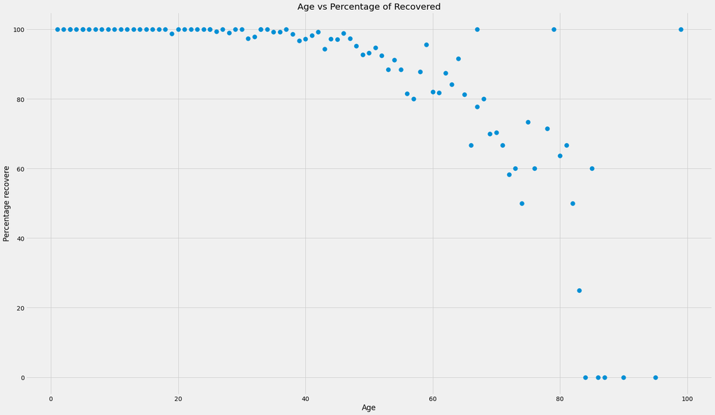

```python
plt.figure(figsize= (25,15))
plt.scatter(df_age_wise['age'], df_age_wise['percentagerecovered'],s=100)
plt.title("Age vs Percentage of Recovered")
plt.ylabel("Percentage recovere")
plt.xlabel("Age")
plt.show()
```

Looks like a polynomial can be fit. Try to fit a degree 3 polynomial to the curve.

```
R2 score(Higher the better) 0.6602022515981376
```

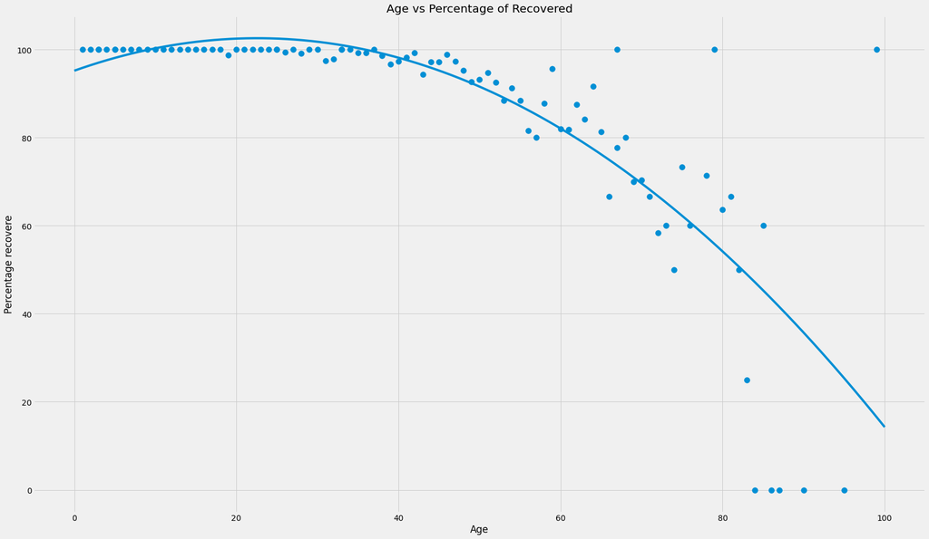

```python
X = df_age_wise['age'].values
y = df_age_wise['percentagerecovered']

model = np.poly1d(np.polyfit(X, y, 3))

print("R2 score(Higher the better)",r2_score(y, model(X)))

line = np.linspace(0, 100, 100)

plt.figure(figsize= (25,15))
plt.scatter(df_age_wise['age'], df_age_wise['percentagerecovered'],s=100)
plt.plot(line, model(line))
plt.title("Age vs Percentage of Recovered")
plt.ylabel("Percentage recovere")
plt.xlabel("Age")
plt.show()
```

Find the equation of polynomial

```python
#find the polynomial
for i in range(len(model.coeffs)):
    if i!= len(model.coeffs)-1:
        print(str(model.coeffs[i])+"x^"+str(len(model.coeffs)-(i+1)), end=' + ')
    else:
        print(str(model.coeffs[i]))
```

```
-2.439673859481172e-06x^3 + -0.014377757586492176x^2 + 0.6528213923429786x^1 + 95.20486203092604
```

Plot Age vs Deceased Percentage

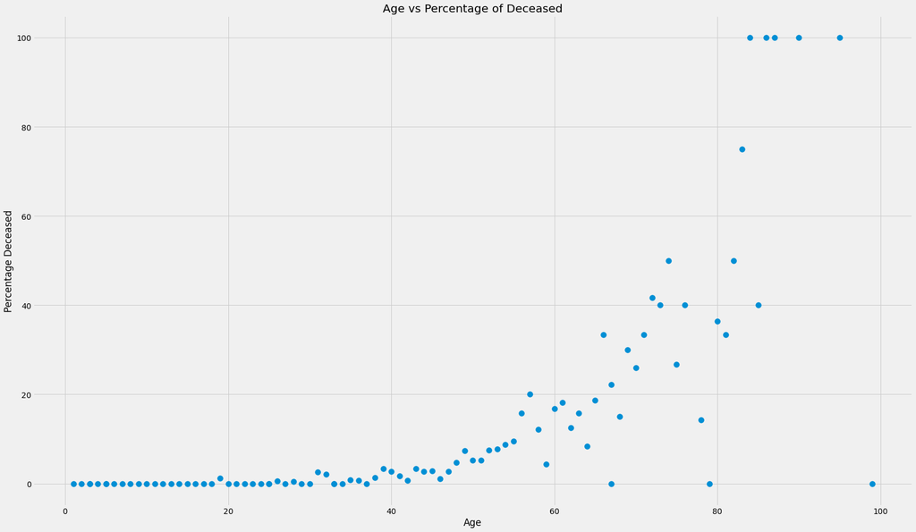

```python
plt.figure(figsize= (25,15))
plt.scatter(df_age_wise['age'], df_age_wise['percentagedeceased'],s=100)
plt.title("Age vs Percentage of Deceased")
plt.ylabel("Percentage Deceased")
plt.xlabel("Age")
plt.show()
```

Try to fit a degree 3 polynomial to the curve.

```
R2 score(Higher the better) 0.6471106562726217
```

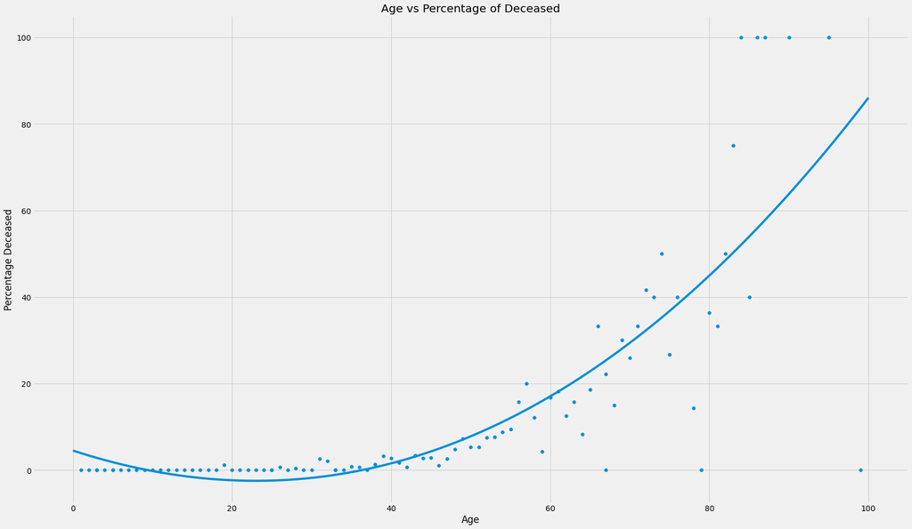

```python
X = df_age_wise['age'].values
y = df_age_wise['percentagedeceased']

model = np.poly1d(np.polyfit(X, y, 3))

print("R2 score(Higher the better)",r2_score(y, model(X)))

line = np.linspace(0, 100, 100)

plt.figure(figsize= (25,15))
plt.scatter(df_age_wise['age'], df_age_wise['percentagedeceased'])
plt.plot(line, model(line))
plt.title("Age vs Percentage of Deceased")
plt.ylabel("Percentage Deceased")
plt.xlabel("Age")
plt.show()
```

Find the equation of polynomial

```python
#find the polynomial
for i in range(len(model.coeffs)):
    if i!= len(model.coeffs)-1:
        print(str(model.coeffs[i])+"x^"+str(len(model.coeffs)-(i+1)), end=' + ')
    else:
        print(str(model.coeffs[i]))
```

```
1.6887240271257296e-05x^3 + 0.012466263051661895x^2 + -0.5997394625621855x^1 + 4.514311566454991
```

Plot Age vs mean disease duration for recovered cases and see if some correlation exists

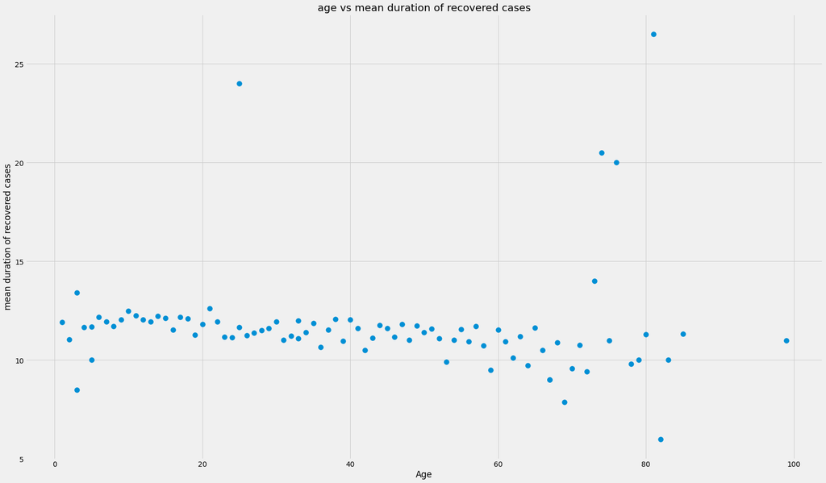

```python
plt.figure(figsize= (25,15))
plt.scatter(df_age_wise['age'], df_age_wise['meanrecovereddduration'], s=100)
plt.title("age vs mean duration of recovered cases")
plt.ylabel("mean duration of recovered cases")
plt.xlabel("Age")
plt.show()
```

We can see that for some of high age(>60) population, average time to recover is very long(>20 days).

Plot Age vs mean disease duration for deceased cases and see if some correlation exists

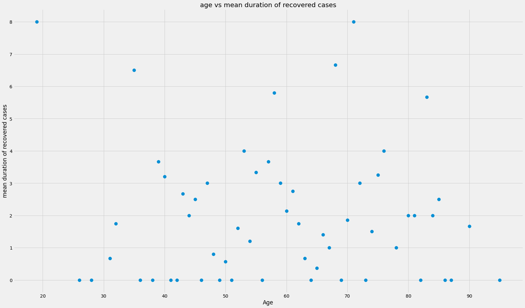

```python
plt.figure(figsize= (25,15))
plt.scatter(df_age_wise['age'], df_age_wise['meandeceasedduration'], s=100)
plt.title("age vs mean duration of recovered cases")
plt.ylabel("mean duration of recovered cases")
plt.xlabel("Age")
plt.show()
```